# Session 3 exercises

Mark Dunning and Matt Eldridge

Last modified: 03 May 2019

Click on the ‘Code’ button on the right hand side to reveal the solution for each plot.

## Part I – ggplot - Facets

These exercises require you to generate plots of various kinds. This document contains both the plots that you should obtain and the solutions (R code).

1. Read in the cleaned patients dataset, `patient-data-cleaned.txt`.

```r
library(tidyverse)
patients <- read_tsv("data/patient-data-cleaned.txt")
patients
```

| ID | Name | Sex | Smokes | Height | Weight | Birth | State | Grade | Died | Count | Date.Entered.Study | Age | BMI | Overweight |
| --- | --- | --- | --- | --- | --- | --- | --- | --- | --- | --- | --- | --- | --- | --- |
| AC/AH/001 | Michael | Male | Non-Smoker | 182.87 | 76.57 | 1972-02-06 | Georgia | 2 | FALSE | 0.01 | 2015-12-01 | 44 | 22.90 | FALSE |
| AC/AH/017 | Derek | Male | Non-Smoker | 179.12 | 80.43 | 1972-06-15 | Colorado | 2 | FALSE | -1.31 | 2015-12-01 | 43 | 25.07 | TRUE |
| AC/AH/020 | Todd | Male | Non-Smoker | 169.15 | 75.48 | 1972-07-09 | New Jersey | 2 | FALSE | -0.17 | 2015-12-01 | 43 | 26.38 | TRUE |
| AC/AH/022 | Ronald | Male | Non-Smoker | 175.66 | 94.54 | 1972-08-17 | Colorado | 1 | FALSE | -1.10 | 2015-12-01 | 43 | 30.64 | TRUE |
| AC/AH/029 | Christine | Female | Non-Smoker | 164.47 | 71.78 | 1973-06-12 | Georgia | 2 | TRUE | 1.42 | 2015-12-01 | 42 | 26.54 | TRUE |
| AC/AH/033 | Dana | Female | Smoker | 158.27 | 69.90 | 1973-07-01 | Indiana | 2 | FALSE | 0.29 | 2015-12-01 | 42 | 27.90 | TRUE |
| AC/AH/037 | Erin | Female | Non-Smoker | 161.69 | 68.85 | 1972-03-26 | New York | 1 | FALSE | 0.16 | 2015-12-01 | 44 | 26.34 | TRUE |
| AC/AH/044 | Rachel | Female | Non-Smoker | 165.84 | 70.44 | 1973-05-11 | Colorado | 1 | FALSE | -0.07 | 2015-12-01 | 42 | 25.61 | TRUE |
| AC/AH/045 | Ronald | Male | Non-Smoker | 181.32 | 76.90 | 1971-12-31 | Georgia | 1 | FALSE | -1.43 | 2015-12-01 | 44 | 23.39 | FALSE |
| AC/AH/048 | Bryan | Male | Non-Smoker | 167.37 | 79.06 | 1973-07-19 | New Jersey | 2 | FALSE | 0.54 | 2015-12-31 | 42 | 28.22 | TRUE |

[output cut: 90 more lines]

1. Using the patient dataset generate a scatter plot of BMI versus Weight, add a colour scale to the scatterplot based on the Height variable, and split the plot into a grid of plots separated by Smoking status and Sex.

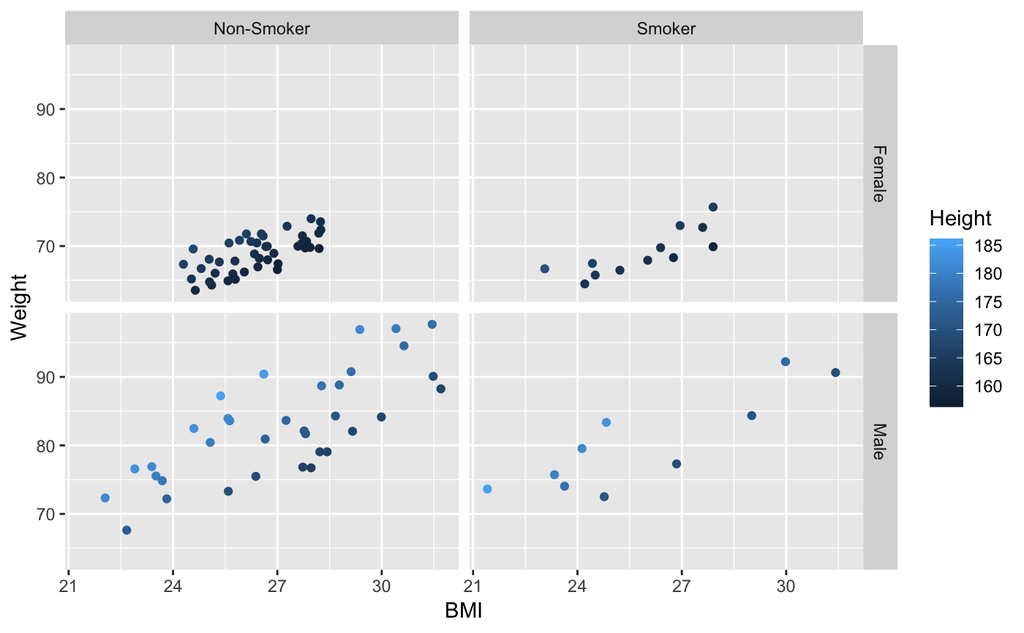

```r
ggplot(data = patients, mapping = aes(x = BMI, y = Weight, colour = Height)) +
  geom_point() +
  facet_grid(Sex ~ Smokes)
```

2. Generate a boxplot of BMIs comparing smokers and non-smokers, colour boxplot by Sex, and include a separate facet for people of different age.

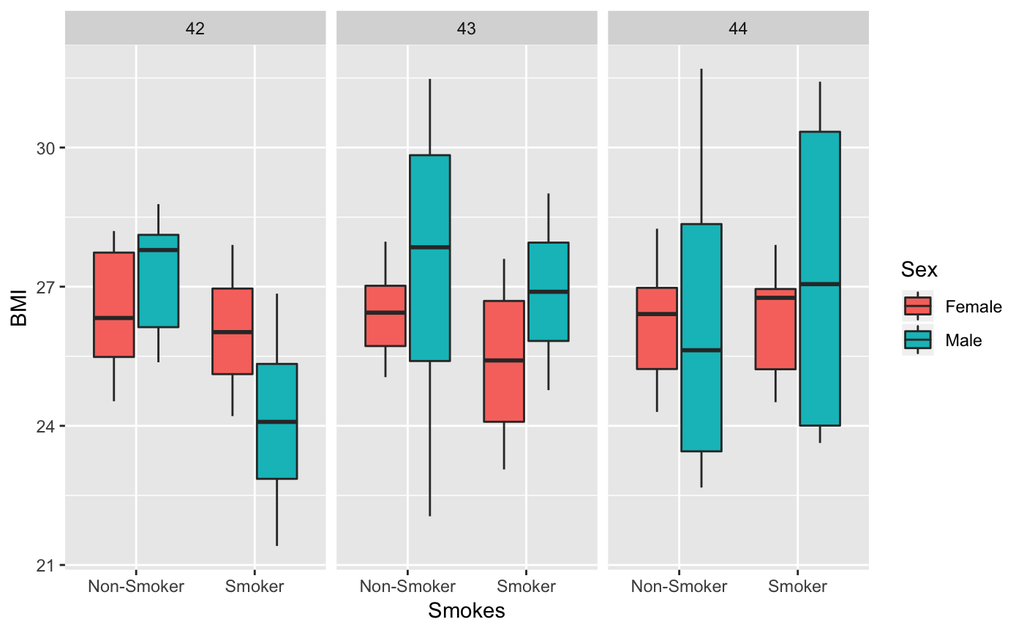

```r
ggplot(data = patients, mapping = aes(x = Smokes, y = BMI, fill = Sex)) +
  geom_boxplot() +
  facet_wrap(~ Age)
```

3. Produce a similar boxplot of BMIs but this time group data by Sex, colour by Age and facet by Smoking status.

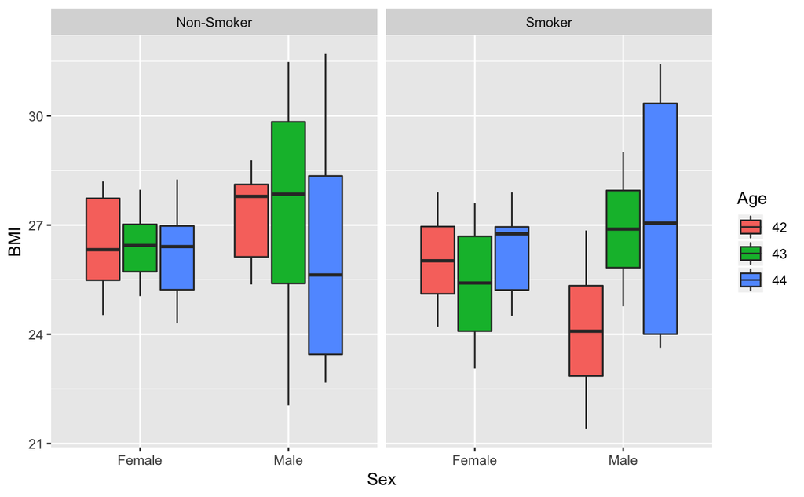

```r
patients$Age <- factor(patients$Age)
ggplot(data = patients, mapping = aes(x = Sex, y = BMI, fill = Age)) +
  geom_boxplot() +
  facet_wrap(~ Smokes)
```

4. Regenerate the solution to exercise 3 but this time using a violin plot.

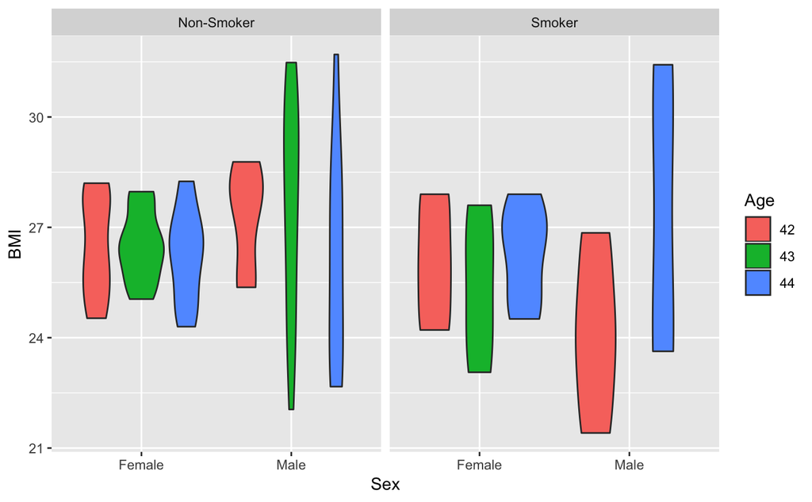

```r
ggplot(data = patients, mapping = aes(x = Sex, y = BMI, fill = Age)) +
  geom_violin() +
  facet_wrap(~ Smokes)
```

5. Generate density plots of BMIs coloured by Sex, and split the plot by Grade.

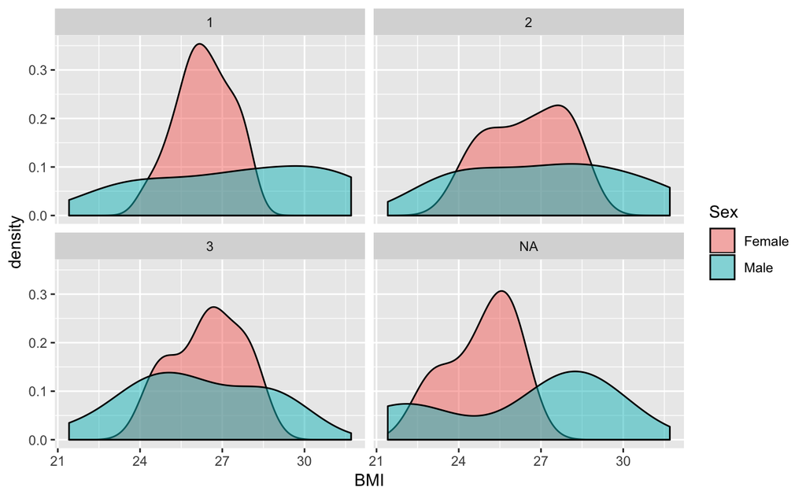

```r
ggplot(data = patients, mapping = aes(x = BMI)) +
  geom_density(aes(fill = Sex), alpha = 0.5) +
  facet_wrap(~ Grade)
```